# KFold

**classsklearn.model_selection.KFold(*n_splits=5*, *, *shuffle=False*, *random_state=None*)[[source]](https://github.com/scikit-learn/scikit-learn/blob/cc50648cc/sklearn/model_selection/_split.py#L437)**

K-Fold cross-validator.

Provides train/test indices to split data in train/test sets. Split dataset into k consecutive folds (without shuffling by default).

Each fold is then used once as a validation while the k - 1 remaining folds form the training set.

Read more in the User Guide.

For visualisation of cross-validation behaviour and comparison between common scikit-learn split methods refer to Visualizing cross-validation behavior in scikit-learn

**Parameters:**

**n_splits**int, default=5**

Number of folds. Must be at least 2.

Changed in version 0.22: `n_splits` default value changed from 3 to 5.

**shuffle**bool, default=False**

Whether to shuffle the data before splitting into batches. Note that the samples within each split will not be shuffled.

**random_state**int, RandomState instance or None, default=None**

When `shuffle` is True, `random_state` affects the ordering of the indices, which controls the randomness of each fold. Otherwise, this parameter has no effect. Pass an int for reproducible output across multiple function calls. See [Glossary](https://scikit-learn.org/1.9/glossary.html#term-random_state).

See also

**`StratifiedKFold`**

Takes class information into account to avoid building folds with imbalanced class distributions (for binary or multiclass classification tasks).

**`GroupKFold`**

K-fold iterator variant with non-overlapping groups.

**`RepeatedKFold`**

Repeats K-Fold n times.

#### Notes

The first `n_samples % n_splits` folds have size `n_samples // n_splits + 1`, other folds have size `n_samples // n_splits`, where `n_samples` is the number of samples.

Randomized CV splitters may return different results for each call of split. You can make the results identical by setting `random_state` to an integer.

#### Examples

```
>>> import numpy as np
>>> from sklearn.model_selection import KFold
>>> X = np.array([[1, 2], [3, 4], [1, 2], [3, 4]])
>>> y = np.array([1, 2, 3, 4])
>>> kf = KFold(n_splits=2)
>>> kf.get_n_splits()
2
>>> print(kf)
KFold(n_splits=2, random_state=None, shuffle=False)
>>> for i, (train_index, test_index) in enumerate(kf.split(X)):
...     print(f"Fold {i}:")
...     print(f"  Train: index={train_index}")
...     print(f"  Test:  index={test_index}")
Fold 0:
  Train: index=[2 3]
  Test:  index=[0 1]
Fold 1:
  Train: index=[0 1]
  Test:  index=[2 3]
```

**get_metadata_routing()[[source]](https://github.com/scikit-learn/scikit-learn/blob/cc50648cc/sklearn/utils/_metadata_requests.py#L1737)**

Get metadata routing of this object.

Please check [User Guide](https://scikit-learn.org/1.9/metadata_routing.html#metadata-routing) on how the routing mechanism works.

**Returns:**

**routing**MetadataRequest**

A `MetadataRequest` encapsulating routing information.

**get_n_splits(*X=None*, *y=None*, *groups=None*)[[source]](https://github.com/scikit-learn/scikit-learn/blob/cc50648cc/sklearn/model_selection/_split.py#L414)**

Returns the number of splitting iterations as set with the `n_splits` param when instantiating the cross-validator.

**Parameters:**

**X**array-like of shape (n_samples, n_features), default=None**

Always ignored, exists for API compatibility.

**y**array-like of shape (n_samples,), default=None**

Always ignored, exists for API compatibility.

**groups**array-like of shape (n_samples,), default=None**

Always ignored, exists for API compatibility.

**Returns:**

**n_splits**int**

Returns the number of splitting iterations in the cross-validator.

**split(*X*, *y=None*, *groups=None*)[[source]](https://github.com/scikit-learn/scikit-learn/blob/cc50648cc/sklearn/model_selection/_split.py#L62)**

Generate indices to split data into training and test set.

**Parameters:**

**X**array-like of shape (n_samples, n_features)**

Training data, where `n_samples` is the number of samples and `n_features` is the number of features.

**y**array-like of shape (n_samples,), default=None**

The target variable for supervised learning problems.

**groups**array-like of shape (n_samples,), default=None**

Always ignored, exists for API compatibility.

**Yields:**

**train**ndarray**

The training set indices for that split.

**test**ndarray**

The testing set indices for that split.

## Gallery examples

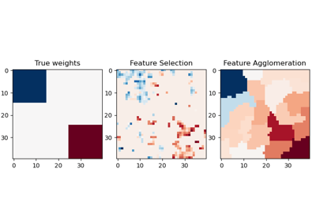

Feature agglomeration vs. univariate selection

[figure not shown]

Comparing Random Forests and Histogram Gradient Boosting models

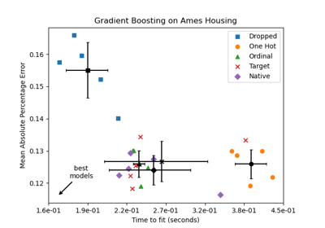

Categorical Feature Support in Gradient Boosting

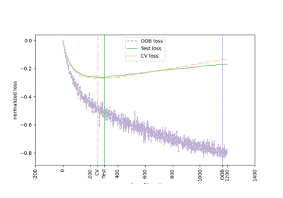

Gradient Boosting Out-of-Bag estimates

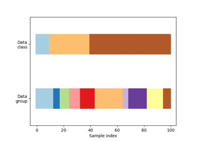

Visualizing cross-validation behavior in scikit-learn

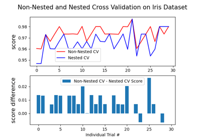

Nested versus non-nested cross-validation

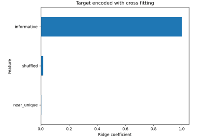

Target Encoder’s Internal Cross fitting

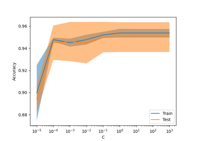

Release Highlights for scikit-learn 1.3

© 2007–2026 The scikit-learn developers  
Licensed under the 3-clause BSD License.  
https://scikit-learn.org/1.9/modules/generated/sklearn.model_selection.KFold.html